# An?lise explorat?ria de dados

Gabriel Cintra

Francisco Edeverton

Maria Clara Dantas

Rafael Guerra

Raimundo Heitor

5 de julho de 2018

Neste markdown iremos realisar uma pequena analise explorat?ria sobre as avalia??es realizadas por pessoas sobre as institui??es ANAC e INSS. Aabaixo est?o as bibliotecas necess?rias e os dados a serem carregados.

```r
#library(tidyverse)
#library(ggplot2)
```

```r
avaliacoes <- read_csv("data/3-avaliacao-humana/avaliacoes-20180610.csv")
reclamacoes <-  read_csv("data/1-reclamacoes-selecionadas/reclamacoes-avaliadas.csv")
```

## 1. Realizando tratamento nos dados

### 1.1. Inserindo colunas comprimento da reclamacao e do titulo

```r
reclamacoes <- reclamacoes %>% mutate(reclamacao.length = str_length(reclamacao),
                                      titulo.length = str_length(titulo))
```

### 1.1. Insere coluna com nÃºmero de letras em capslock

```r
reclamacoes$numero.de.capslock <- str_count(reclamacoes$reclamacao, "\\b[A-Z]{2,}\\b")
```

## H? alguma rela??o entre o n?vel de instatisfa??o geral das reclama??es e o n?mero de palavras em caixa alta presentes nelas?

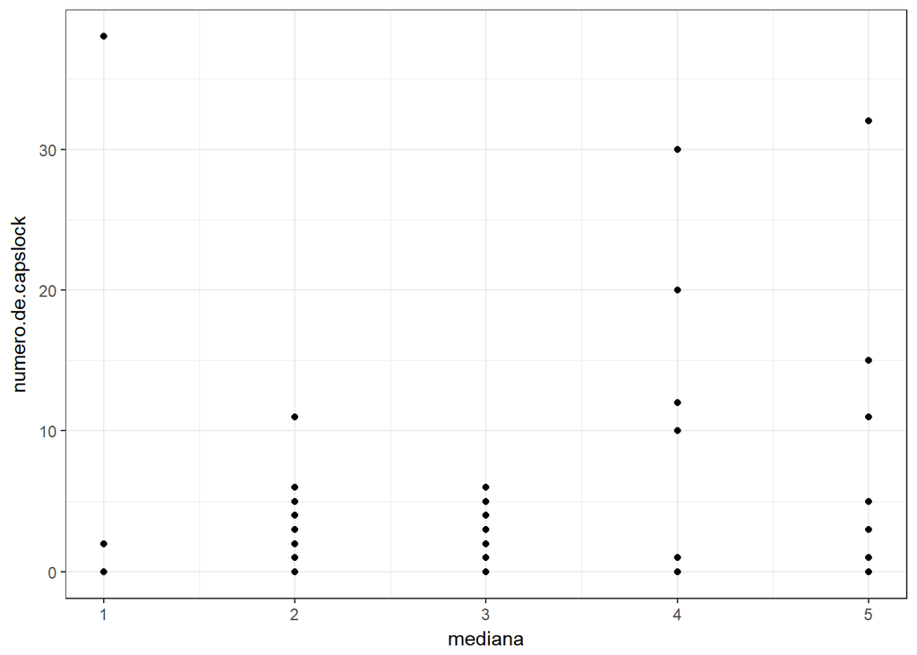

```r
ggplot(reclamacoes, aes(x=mediana, y=numero.de.capslock)) + geom_point()
```

Com este plot, percebemos h? pouca rela??o entre as duas vari?veis. A reclama??o com maior n?mero de palavras em caixa alta, tem o menor n?vel de instatisfa??o geral baixa, enquanto que h? reclama??es com poucas ou nenhuma palavra em caixa alta que possuem o maior n?vel de insatisfa??o geral. Isso se confirma dado o baixo coeficiente de correla??o entre as duas variaveis:

```r
cor(reclamacoes$mediana, reclamacoes$numero.de.capslock)
```

```
## [1] 0.2026066
```

## Das avalia??es realzadas, quantas foram feitas para cada n?vel de insatisfa??o?

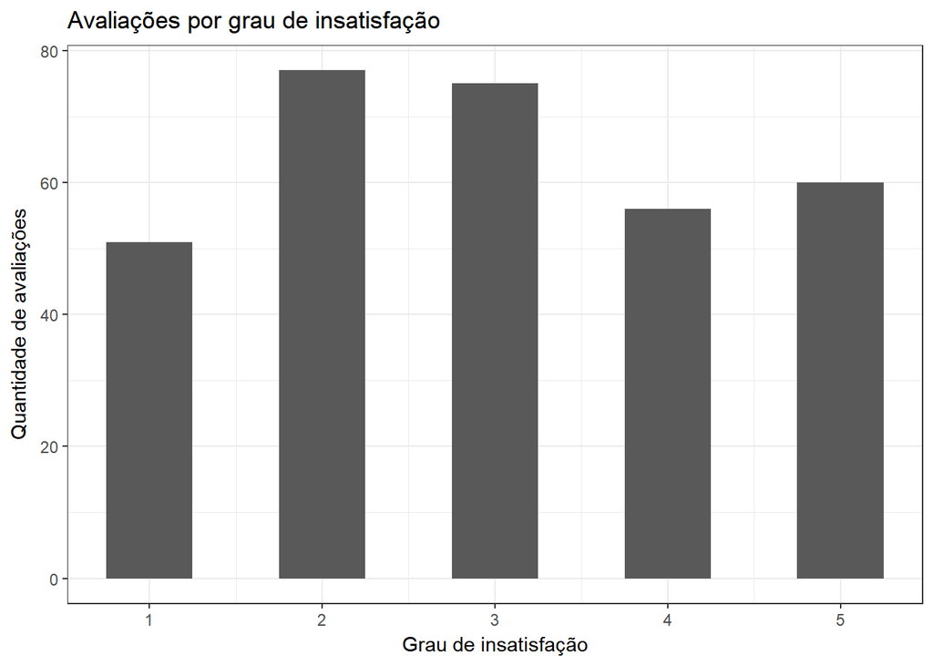

```r
ggplot(avaliacoes, aes(x = `Grau de insatisfação`)) + geom_bar(binwidth = 0.5) + labs(title = "Avaliações por grau de insatisfação", x="Grau de insatisfação", y="Quantidade de avaliações")
```

## Dos dois órgãos apresentados, como estão distribuidas as avaliações com grau maximo de insatisfação?

A partir daqui, iremos alterar um pouco a frame de avaliações para facilitar a análise

```r
avaliacoes <- avaliacoes %>% select(id = `ID da reclamação`,
         insatisfacao = `Grau de insatisfação`)
```

Agora, observe o plot abaixo

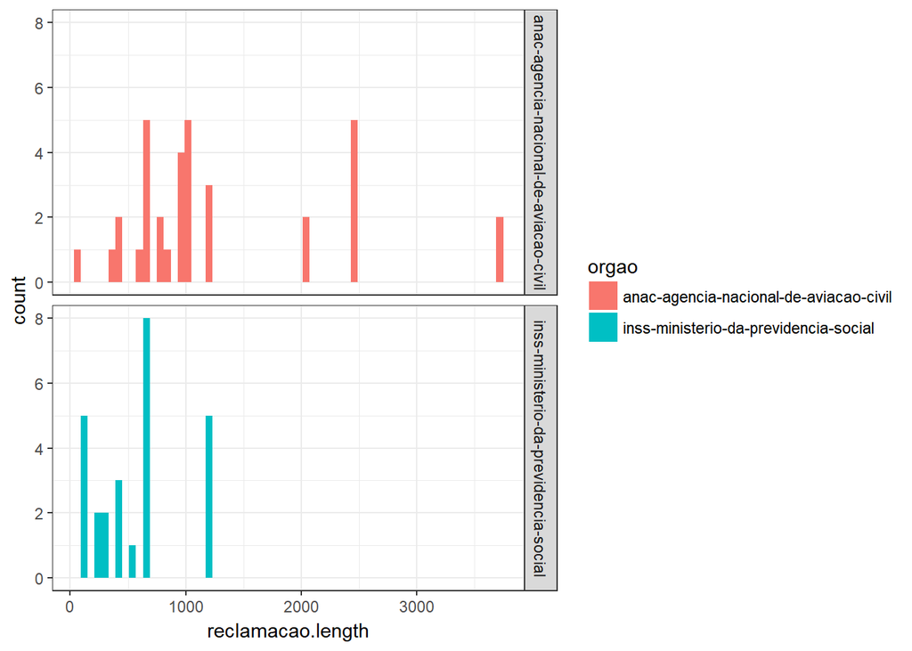

```r
avaliacoes %>% group_by(id) %>% filter(insatisfacao >= 5) %>% inner_join(reclamacoes, by = "id") %>% ggplot(aes(fill = orgao, x = reclamacao.length), na.rm = TRUE) +
geom_histogram(binwidth = 60, na.rm = TRUE) + facet_grid(orgao ~ .)
```